# Evaluación de un modelo de clasificación

Author

Carolina Armella, Ágatha del Olmo y María Yu García

Published

October 18, 2024

## 1. Introducción

Este documento explica con un ejemplo práctico de evaluación de solicitudes de crédito (credit scoring), cómo se calculan las métricas clave para analizar la efectividad de un modelo que clasifica si se debe conceder o no un préstamo. El enfoque está en cómo evaluar el desempeño del modelo, no en los detalles técnicos del modelo en sí. En este caso, se utiliza un árbol de decisión creado con el paquete C50 de R, que es necesario instalar si se desea replicar los resultados presentados.

## 2. Datos y Antecedentes

Para implementar un sistema automatizado de evaluación crediticia (credit scoring), es fundamental contar con modelos que permitan identificar con precisión los riesgos asociados a los préstamos. Además, la normativa bancaria en muchos países, incluido España, exige que las instituciones expliquen a los solicitantes los motivos para aceptar o rechazar una solicitud de crédito. Por ello, los modelos empleados deben ser transparentes. Herramientas más avanzadas como las redes neuronales o los modelos de máquinas de soporte vectorial (SVM) son consideradas “cajas negras” y no son fáciles (y a veces son imposibles) de interpretar y por lo tanto no cumplen con este requisito de transparencia.

El objetivo principal de un sistema de evaluación crediticia es identificar los factores que hacen que una solicitud tenga un riesgo alto. Para ello, se utilizan datos históricos sobre préstamos anteriores, características de los solicitantes y su historial de cumplimiento (o impago). En este ejemplo, trabajamos con un conjunto de datos basado en un archivo donado por Hans Hofmann de la Universidad de Hamburgo al UCI Machine Learning Data Repository, que contiene información sobre préstamos de una agencia crediticia alemana.

```r
creditos <- read.csv("http://www.uv.es/pavia/MCD/credit.csv", sep=";",
                     stringsAsFactors = TRUE)

table(creditos$default)
```

```
No-Default Si-Default
       700        300
```

La variable default informa sobre la condición de fallido o no del préstamo. Hay 300 créditos fallidos y 700 pagados.

### Algoritmo de predicción

Tras analizar los datos y estudiar sus características principales, hemos optado por un algoritmo de clasificación que sea fácil de interpretar. Para este caso, emplearemos árboles de decisión.

Este tipo de modelo presenta las predicciones de forma visual y lógica, lo que permite que cualquier persona, incluso sin conocimientos técnicos de estadística, pueda comprender los resultados. En particular, utilizaremos el algoritmo C5.0, que es una versión mejorada del conocido C4.5. En el entorno de programación R, este algoritmo se encuentra disponible a través del paquete C50.

```r
set.seed(11111)
credit <- creditos[sample(1:1000),]

train <- credit[1:900,]
test <- credit[901:1000,]


prop.table(table(train$default))
```

```
No-Default Si-Default
 0.7022222  0.2977778
```

```r
prop.table(table(test$default))
```

```
No-Default Si-Default
      0.68       0.32
```

Para construir y evaluar el modelo, dividimos la base de datos en dos conjuntos: 900 registros para el training set y 100 para el test set.

**Separación del dataset**

- Training set: Este conjunto se utiliza para entrenar el modelo. Contiene ejemplos históricos con características de préstamos y la información de si fueron pagados o no. El modelo analiza estos datos para identificar patrones que permitan clasificar a futuros solicitantes como buenos pagadores o posibles impagados.
- Test set: Este segundo conjunto se emplea para evaluar la efectividad del modelo en datos que no ha visto antes. Sirve para comprobar si el modelo es capaz de reconocer patrones en casos nuevos y, por tanto, si sería útil para predecir con precisión en situaciones reales.

Analizamos la proporción de préstamos pagados e impagados en el conjunto de entrenamiento para asegurarnos de que sea similar a la base de datos original. Esto es crucial porque garantiza que el modelo aprenda en un contexto representativo, con suficientes casos impagados para predecir correctamente en casos reales. Lo mismo pasa con la del test, que es necesario para que estudie correctamente si es un modelo eficaz con ejemplos que no ha visto.

## 3. Modelos

### Modelo 1. Por defecto.

```r
modelo <- C5.0(subset(train, select = -default), train$default)

C5imp(modelo)
```

```
                     Overall
checking_balance      100.00
other_debtors          56.33
installment_plan       54.22
savings_balance        49.89
months_loan_duration   38.44
credit_history         38.22
purpose                18.67
installment_rate       18.56
employment_length      11.44
personal_status         8.89
housing                 7.89
amount                  4.89
job                     4.89
residence_history       4.56
telephone               4.44
property                4.22
dependents              3.22
age                     0.78
existing_credits        0.56
foreign_worker          0.00
```

```r
prediccion_train <- predict(modelo, train)
table(train$default, prediccion_train)
```

```
            prediccion_train
             No-Default Si-Default
  No-Default        602         30
  Si-Default         88        180
```

```r
CrossTable(train$default, prediccion_train, prop.chisq = FALSE,
           prop.c = FALSE, prop.r = FALSE,
           dnn = c('REAL', 'PREDICCION'))
```

```
   Cell Contents
|-------------------------|
|                       N |
|         N / Table Total |
|-------------------------|


Total Observations in Table:  900


             | PREDICCION
        REAL | No-Default | Si-Default |  Row Total |
-------------|------------|------------|------------|
  No-Default |        602 |         30 |        632 |
             |      0.669 |      0.033 |            |
-------------|------------|------------|------------|
  Si-Default |         88 |        180 |        268 |
             |      0.098 |      0.200 |            |
-------------|------------|------------|------------|
Column Total |        690 |        210 |        900 |
-------------|------------|------------|------------|
```

#### Una primera evaluación del modelo

Primero construimos el modelo que nos da R por defecto para clasificar los préstamos, sin modificar sus parámetros. Este modelo tiene una tendencia a sobreajustar, lo que significa que aprende demasiado bien los detalles específicos de los datos usados para entrenarlo, lo cual puede ser un problema porque podría no funcionar tan bien con datos nuevos, ya que pierde capacidad de generalizar.

**Sobreajuste**

El sobreajuste implica una tendencia a subestimar el error, es decir, el modelo parece funcionar mejor de lo que realmente lo haría con datos nuevos. Esto ocurre porque el modelo se ajusta mucho a los datos que ya conoce y, por tanto, no refleja bien lo que podría pasar con datos futuros.

En este caso, el modelo no clasificó correctamente 118 casos, es decir, un error del 13.11%.

**Tipos de error**

- Falsos negativos: Son casos que deberían haber sido clasificados como fallidos pero el modelo los marcó como no fallidos. Esto es especialmente preocupante porque podría llevar a conceder préstamos de alto riesgo sin darse cuenta.
- Falsos positivos: Son casos que en realidad eran no fallidos pero el modelo los clasificó como fallidos. Esto podría causar que se rechacen solicitudes de crédito que en realidad eran seguras.

Para realmente estudiar si con casos reales sería un buen modelo, usamos el conjunto de test para predecir con el modelo. Luego comparamos con lo que realmente pasó, si se pagó o no y generamos de nuevo la matriz de confusión, que nos indica los verdaderos y falsos negativos con casos nuevos.

```r
prediccion_test <- predict(modelo, test)

table(test$default, prediccion_test)
```

```
            prediccion_test
             No-Default Si-Default
  No-Default         54         14
  Si-Default         15         17
```

```r
CrossTable(test$default, prediccion_test, prop.chisq = FALSE,
           prop.c = FALSE, prop.r = FALSE,
           dnn = c('REAL', 'PREDICCION'))
```

```
   Cell Contents
|-------------------------|
|                       N |
|         N / Table Total |
|-------------------------|


Total Observations in Table:  100


             | PREDICCION
        REAL | No-Default | Si-Default |  Row Total |
-------------|------------|------------|------------|
  No-Default |         54 |         14 |         68 |
             |      0.540 |      0.140 |            |
-------------|------------|------------|------------|
  Si-Default |         15 |         17 |         32 |
             |      0.150 |      0.170 |            |
-------------|------------|------------|------------|
Column Total |         69 |         31 |        100 |
-------------|------------|------------|------------|
```

El error global en el conjunto de test es del 0.15 + 0.14 = 29%.

54 casos fueron predichos correctamente como pagados y 17 casos fueron predichos correctamente como impagados. 14 casos fueron predichos incorrectamente como impagados, cuando en realidad eran pagados (falsos positivos). 15 casos fueron predichos incorrectamente como pagados, cuando en realidad eran impagados (falsos negativos).

**Tasa de error**

Falsos positivos: 14 (personas clasificadas como “Si-Default” que realmente no incumplieron). Falsos negativos: 15 (personas clasificadas como “No-Default” que realmente incumplieron). Precisión general: La precisión general del modelo es la proporción de predicciones correctas (54 + 17) sobre el total (100), lo que da una precisión de: 0.71 (54)

El error global del modelo se puede calcular como la proporción de predicciones incorrectas:

Predicciones incorrectas:

14 (falsos positivos) + 15(falsos negativos) = 29

Total de casos: 100

El error global del modelo es: 29/100 = 0.29 - 29%

Por lo tanto, tenemos un 100% - 29% = 71% de precisión.

Es interesante estudiar que en la matriz de confusión hay 68 de los 100 casos que son realmente pagados. Entonces, si un modelo predijera siempre que los usuarios van a pagar correctamente el préstamo, sería correcto en 68 de 100 casos, un 68%. Como acabamos de ver, nuestro modelo actual tiene una precisión del 71%, lo que es mejor que un modelo trivial que prediga pagado para todos los casos. Por lo tanto, nos damos cuenta de que hay un gran margen de mejora a través del tuneado (modificación) de los parámetros del modelo.

#### ¿Qué umbral se está utilizando?

El modelo utiliza la función predict(modelo, test) del paquete C50, que por defecto utiliza un umbral del 0.5, que es un umbral bastante común. Esto significa que en el caso de que la probabilidad de que un ejemplo sea pagado sea mayor o igual al 50%, clasifica el ejemplo como pagado. En cambio, si la probabilidad es menor al 50%, lo clasifica como impagado.

#### Mejorando el modelo

Como hemos mencionado, el error del modelo es muy alto para ser empleado en una situación real, un modelo que predijese pagado para todos los casos, por pura probabilidad, habría sido correcto prácticamente el 70% del tiempo (casi igual que nuestro modelo). Además, es especialmente malo prediciendo los casos de impago, casi un 50% de error, cuando este es el error más costoso para la empresa ya que se le concedería un préstamo a una persona con altas probabilidades de impago.

Alternativas para mejorarlo son: - Utilizar boosting (para mejorar el ajuste global). - Dar diferente peso a cada tipo de error (para mejorar el ajuste en la clase de interés).

### Modelo 2. Boosting

Primero exploramos el método de boosting, que mejora las predicciones combinando varios modelos más simples, en este caso, árboles de decisión con menor capacidad predictiva. El boosting utiliza una técnica llamada remuestreo, que consiste en entrenar varios modelos pequeños resultantes de la base de datos original y luego combinarlos para crear una capacidad predictiva final más precisa y robusta. Esta estrategia es muy interesante ya que permite corregir los errores de cada modelo individual y mejorar el rendimiento global.

Probamos con dos modelos con diferente número de trials

```r
modelo_boost_10 <- C5.0(subset(train, select = -default), train$default, trials = 10)

prediccion_boost_10 <- predict(modelo_boost_10, test)

modelo_boost_50 <- C5.0(subset(train, select = -default), train$default, trials = 50)

prediccion_boost_50 <- predict(modelo_boost_50, test)
```

Entrenamos el modelo nuevamente con el conjunto de training, pero esta vez construimos dos versiones con diferentes números de trials (10 y 50) para comparar sus resultados. Los trials representan la cantidad de modelos individuales combinados en el proceso de boosting. A medida que aumentamos los trials, podemos observar cómo varía la precisión del modelo utilizando la matriz de confusión, que muestra cuántas predicciones fueron correctas o incorrectas para cada uno. Esto nos permite evaluar si más trials realmente mejoran el rendimiento o si llegan a sobreajustar el modelo como antes.

**Umbrales generales de trials**

- Pocos trials (1-5): Resultados similares a un solo árbol de decisión.
- Trials moderados (10-50): Mejora significativa en la precisión y reducción del sesgo.
- Muchos trials (>50): Riesgo de sobreajuste, aunque con posibles pequeñas mejoras adicionales.

El tiempo de entrenamiento aumenta con mayor número de trials, por lo que es importante equilibrar el número de trials con los recursos disponibles.

```r
CrossTable(test$default, prediccion_boost_10, prop.chisq = FALSE,
           prop.c = FALSE, prop.r = FALSE, dnn = c('REAL', 'PREDICCION'))
```

```
   Cell Contents
|-------------------------|
|                       N |
|         N / Table Total |
|-------------------------|


Total Observations in Table:  100


             | PREDICCION
        REAL | No-Default | Si-Default |  Row Total |
-------------|------------|------------|------------|
  No-Default |         56 |         12 |         68 |
             |      0.560 |      0.120 |            |
-------------|------------|------------|------------|
  Si-Default |         17 |         15 |         32 |
             |      0.170 |      0.150 |            |
-------------|------------|------------|------------|
Column Total |         73 |         27 |        100 |
-------------|------------|------------|------------|
```

```r
CrossTable(test$default, prediccion_boost_50, prop.chisq = FALSE,
           prop.c = FALSE, prop.r = FALSE, dnn = c('REAL', 'PREDICCION'))
```

```
   Cell Contents
|-------------------------|
|                       N |
|         N / Table Total |
|-------------------------|


Total Observations in Table:  100


             | PREDICCION
        REAL | No-Default | Si-Default |  Row Total |
-------------|------------|------------|------------|
  No-Default |         54 |         14 |         68 |
             |      0.540 |      0.140 |            |
-------------|------------|------------|------------|
  Si-Default |         17 |         15 |         32 |
             |      0.170 |      0.150 |            |
-------------|------------|------------|------------|
Column Total |         71 |         29 |        100 |
-------------|------------|------------|------------|
```

Estos resultados en cambio nos enseñan cómo el modelo con 50 iteraciones de boosting ha clasificado los casos. El error global sube un 2% a un 31%, y muestra un leve aumento en el error de falsos positivos de 12 a 14 respecto al de 10 trials, mientras que el otro error se mantiene constante. Esto sugiere que, como hemos mencionado antes, más trials puede llevar a un sobreajuste en los datos de entrenamiento. En general, los 50 trials no han proporcionado una mejora en el error crítico con respecto a los 10 trials, y de hecho han empeorado el error contrario, que aunque no sea tan crítico, también nos lleva a perder oportunidades de negocio al no conceder préstamos a quienes lo iban a devolver correctamente.

### Modelo 3. Costes asimétricos

Ahora, estudiamos la segunda alternativa para mejorar el modelo: el uso de costes asimétricos, que consiste en asignar una mayor importancia a un error de forma que el modelo se enfoque en reducir el mismo. Usar costes asimétricos en este caso ayuda a darle más importancia a evitar los falsos negativos, es decir, hacer que el modelo sea más cuidadoso con los préstamos arriesgados, aunque a veces rechace algunos que realmente serían buenos. Esto es esencial para reducir el riesgo financiero.

Para nuestro caso, hemos definido en la matriz de costes que no haya ningún coste en acertar y que el coste de un falso negativo sea 4 veces mayor que el coste de un falso positivo.

#### Ajuste del modelo

```r
modelo_cost <- C5.0(subset(train, select = -default),
                       train$default, costs = error_cost)

prediccion_cost <- predict(modelo_cost, test)
```

De nuevo, ajustamos el modelo con el training set, pero esta vez le especificamos la matriz de costes.

```r
CrossTable(test$default, prediccion_cost, prop.chisq = FALSE,
           prop.c = FALSE, prop.r = FALSE,
           dnn = c('REAL', 'PREDICCION'))
```

```
   Cell Contents
|-------------------------|
|                       N |
|         N / Table Total |
|-------------------------|


Total Observations in Table:  100


             | PREDICCION
        REAL | No-Default | Si-Default |  Row Total |
-------------|------------|------------|------------|
  No-Default |         34 |         34 |         68 |
             |      0.340 |      0.340 |            |
-------------|------------|------------|------------|
  Si-Default |          5 |         27 |         32 |
             |      0.050 |      0.270 |            |
-------------|------------|------------|------------|
Column Total |         39 |         61 |        100 |
-------------|------------|------------|------------|
```

- ¿Qué ha pasado con el error global?
- ¿Y con los errores de clasificación?

Vamos a aprovechar y comparar los modelos de boosting y el de costes con el modelo de base:

En comparación con el modelo base de C5.0, el error global ha aumentado en 10 puntos (39%) en el modelo de costes, se ha quedado igual (29%) en el de boosting 10, y en el de boosting 50 ha aumentado 2 puntos (31%). Esto puede sugerir que estos enfoques han empeorado en general la capacidad con un error global relativamente alto.

En el caso del boosting, se observa que el error global aumenta a medida que aumentamos el número de iteraciones o trials (de 10 a 50). Esto ocurre porque a pesar de que cada árbol generado durante el proceso pone mayor atención en las instancias mal clasificadas previamente, probablemente estamos incurriendo en un sobreajuste.

#### Evaluando clasificaciones

Ahora, vamos a extraer distintas métricas con las predicciones del modelo pero usando el test set, lo cual nos asegura que la evaluación del modelo sea realista y refleje su desempeño en datos nuevos, ayudando a validar su efectividad en la toma de decisiones.

```r
predic_prob <- predict(modelo, test, type='prob')
```

```r
data.frame(predic_prob, test$default)
```

[output not shown]

## 4. Medidas de calidad de predicción en clasificación

- Accuracy y error rate.
- Estadístico Kappa
- Sensitivity y Specifity
- Precision y sensibilidad
- F-Score
- Curva ROC y AUC

```r
CrossTable(test$default, prediccion_test,
           dnn = c('REAL', 'PREDICCION'))
```

```
   Cell Contents
|-------------------------|
|                       N |
| Chi-square contribution |
|           N / Row Total |
|           N / Col Total |
|         N / Table Total |
|-------------------------|


Total Observations in Table:  100


             | PREDICCION
        REAL | No-Default | Si-Default |  Row Total |
-------------|------------|------------|------------|
  No-Default |         54 |         14 |         68 |
             |      1.068 |      2.378 |            |
             |      0.794 |      0.206 |      0.680 |
             |      0.783 |      0.452 |            |
             |      0.540 |      0.140 |            |
-------------|------------|------------|------------|
  Si-Default |         15 |         17 |         32 |
             |      2.270 |      5.053 |            |
             |      0.469 |      0.531 |      0.320 |
             |      0.217 |      0.548 |            |
             |      0.150 |      0.170 |            |
-------------|------------|------------|------------|
Column Total |         69 |         31 |        100 |
             |      0.690 |      0.310 |            |
-------------|------------|------------|------------|
```

### Evaluando la clasificación

```r
conf <- confusionMatrix(prediccion_test , test$default,
                positive = "Si-Default")
```

```r
sensitivity <- sensitivity(prediccion_test , test$default, positive = "Si-Default")

specificity <- specificity(prediccion_test , test$default, negative = "No-Default")

ppv<- posPredValue(prediccion_test, test$default,
             positive = "Si-Default")
```

### Curva ROC y AUC

```
integer(0)
```

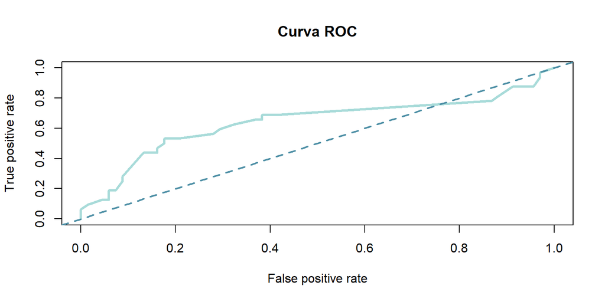

```r
prob_test <- predict(modelo, test, type='prob')
pred <- prediction(predictions = prob_test[,2],
                   labels = test$default)

perf <- performance(pred, measure = "tpr", x.measure = "fpr")

plot(perf, main = "Curva ROC", col = colores[2], lwd = 3) +
abline(a = 0, b = 1, lwd = 2, lty = 2, col = colores[5])
```

```r
perf.auc <- performance(pred, measure = "auc")@y.values
perf.auc
```

```
[[1]]
[1] 0.640625
```

## 5.Calcula todas las medidas de evaluación no obtenidas con el código previo.

### Accuracy y error rate

**Accuracy y Error rate**

El accuracy nos indica cuánto hemos acertado en un sentido global, es decir, cuán cerca estuvieron las predicciones de la realidad.

$Accuracy=\frac{TP+TN}{TP+TN+FP+FN}$

El error rate indica cuánto nos hemos equivocado en sentido global, contrario al accuracy.

$Error\space rate=\frac{FP+FN}{TP+TN+FP+FN}$

Como vemos, debemos calcular TP, TN, FP y FN que provienen de la matriz de confusión:

- True Positive (TP): instancias correctamente predichas en la clase de interés (Sí-Default).
- True Negative (TN): instancias correctamente predichas en la clase alternativa (No-Default).
- False Positive (FP): instancias incorrectamente predichas en la clase de interés (Sí-Default).
- False Negative (FN): instancias incorrectamente predichas en la clase de alternativa (No-Default).

```r
tp <- conf$table[2,2]
tn <- conf$table[1,1]
fp <- conf$table[2,1]
fn <- conf$table[1,2]
```

Tras extraer estas métricas de la matriz de confianza podemos calcular el accuracy.

```r
accuracy <- (tp+tn) / (tp+tn+fp+fn)
accuracy
```

```
[1] 0.71
```

```r
error_rate <- (fp+fn) / (tp+tn+fp+fn)
error_rate
```

```
[1] 0.29
```

Este resultado nos indica que el modelo está clasificando correctamente el 71% de los casos y erróneamente el 29%, lo que puede parecer que indica que es un modelo medianamente bueno, pero cabe destacar que cuando la base de datos está desequilibrada, como en nuestro caso, el accuracy podría ser engañoso.

### Kappa

Para entender el estadístico Kappa debemos comprender los conceptos siguientes:

· Coincidencia observada (Po): Es el porcentaje de veces que el modelo predice correctamente, es decir, el accuracy.

· Coincidencia esperada (Pe): Es la coincidencia que se esperaría si las predicciones fueran hechas aleatoriamente en promedio.

**Kappa**

La métrica Kappa mide la diferencia entre $P_o$ y $P_e$, de forma que si $Kappa=0$, entonces la coincidencia entre predicciones y observaciones es producto del azar, mientras que si $Kappa=1$, el modelo ha conseguido una coincidencia perfecta por encima del azar.

La fórmula del Kappa es la siguiente:

$kappa=\frac{(po-pe)}{(1-pe)}$

Siendo el $p_e$:

$pe=(prp*ppp)+(prn*ppn)$

Donde *prp* y *prn* son las proporciones reales de la clase positiva y negativa, y *ppp* y *ppn* las proporciones predichas de las mismas (proporciones de los valores de la matriz de confusión).

Primero calculamos las proporciones reales de positivos y negativos, y comprobamos que su suma da 1.

```r
prp <- (tp+fp)/100
prn <- (tn+fn)/100

prp+prn
```

```
[1] 1
```

Repetimos el mismo proceso para las proporciones predichas:

```r
ppp <- (tp+fn)/100
ppn <- (fp+tn)/100

ppp+ppn
```

```
[1] 1
```

Y ahora podemos sustituirlas en la fórmula:

```r
pe <- (ppp*prp)+(ppn*prn)
pe
```

```
[1] 0.5684
```

Finalmente, recordando que $p_o$ viene a ser accuracy, podemos calcular el Kappa con su fórmula:

```r
po <- accuracy
po
```

```
[1] 0.71
```

```r
kappa <- (po-pe)/(1-pe)
```

Como el cálculo del Kappa es más complejo que el de otras métricas, lo comparamos con el que extraemos de la matriz de confusión a través del atributo overall. El atributo overall es un conjunto de métricas que obtiene automáticamente R al analizar la matriz de confusión, y entre ellos está el Kappa. Aunque este método es más rápido, calcularlo paso a paso nos ayuda a entender mejor cómo funciona y qué mide realmente esta métrica. Comprobamos que lo hemos calculado correctamente:

```r
kappa2 <- conf$overall[2]

kappa==kappa2
```

```
Kappa
 TRUE
```

```r
kappa
```

```
[1] 0.3280816
```

El resultado del Kappa nos indica que el modelo tiene un nivel de predicción que es un 32.8% mejor que si estuviera adivinando al azar, lo cual es una coincidencia débil. Es decir, el modelo tiene cierta capacidad predictiva, pero podemos atribuir una gran parte de las predicciones al azar.

### F-score

**F-Score**

El F-score es una métrica muy utilizada en problemas en los que el conjunto de datos a analizar está desbalanceado, como suele ser el caso de la detección de fraudes, y como sabemos, en efecto, que es nuestro caso.

En concreto, es una media ponderada harmónica entre precisión y sensibilidad que define qué tan bien el modelo equilibra ambos aspectos para evaluar su rendimiento general. Un buen equilibrio asegura que el modelo sea útil en ambos sentidos: que detecte bien los casos críticos (como impagos) y que no haga demasiados errores innecesarios en las demás predicciones.

$Fscore = \frac{2}{\frac{1}{Precision}+\frac{1}{sensibilidad}}$

Calculamos el F-Score paso a paso:

```r
sensibilidad <- tp / (tp+fn)
sensibilidad
```

```
[1] 0.53125
```

```r
fscore <- 2/((1/ppv + 1/sensibilidad))
```

También podemos calcular el F-Score fácilmente usando el resultado de la función confusionMatrix() que guardamos anteriormente en el objeto conf. Dentro de este objeto, está el atributo byClass, que es similar al atributo overall, en este caso nos puede dar directamente el valor del F-Score ya calculado. Es una forma rápida de obtenerlo sin hacer los cálculos manualmente.

```r
fscore2 <- conf$byClass[7]
```

Comprobamos que ambos nos dan lo mismo:

```r
fscore==fscore2
```

```
  F1
TRUE
```

```r
fscore
```

```
[1] 0.5396825
```

Para interpretar este resultado tenemos que entender que el F-Score va de 0 a 1.

**F-Score**

- $F-Score = 1$: Precisión y sensibilidad perfectas, el modelo funciona excelente.
- $F-Score = 0$: El modelo no identifica ningún caso correctamente.
- $F-Score ≈ 0.5$: El rendimiento del modelo es moderado, ni bueno ni malo.

Un F-Score alrededor de 0.5 indica que hay cierto equilibrio entre precisión y sensibilidad, pero el modelo aún tiene mucho espacio para mejorar. Un valor de aproximadamente un 0.5 implica un rendimiento moderado del modelo, es decir, ni excelente, ni completamente deficiente. Hay cierto balance entre precisión y sensibilidad, pero nos deja un gran margen de mejora.

## 6. Medidas de evaluación para el resto de modelos

Para evaluar el resto de modelos creamos una función que nos extraiga cada una de las métricas de evaluación, y como ya hemos utilizado distintos métodos para explicar cada una con el modelo c.50, vamos a simplificar el proceso sacando cada métrica de la matriz de confianza.

**Mostrar código**

```r
metricas <- function(modelo_func) {

  prediccion_test_func <- predict(modelo_func, test)

  if (modelo_func$cost == "") {
    # Con probabilidades
    prediccion_test_prob <- predict(modelo_func, test, type = 'prob')

    conf_func <- confusionMatrix(prediccion_test_func, test$default,
                                 positive = "Si-Default")

    pred_func <- prediction(predictions = prediccion_test_prob[, 2],
                            labels = test$default)

    perf_func <- performance(pred_func, measure = "tpr", x.measure = "fpr")

    auc_func <- performance(pred_func, measure = "auc")@y.values[[1]]

    resultados <- data.frame(
      Metric = c("Accuracy", "Error Rate", "Kappa", "Sensitivity",
                 "Specificity", "Precision", "F1 Score", "AUC"),
      Value = c(conf_func$overall[1],
                1 - conf_func$overall[1],
                conf_func$overall[2],
                conf_func$byClass[1],
                conf_func$byClass[2],
                conf_func$byClass[6],
                conf_func$byClass[7],
                auc_func)
    )

    plot(perf_func, main = "Curva ROC", col = colores[2], lwd = 3)
    abline(a = 0, b = 1, lwd = 2, lty = 2, col = colores[5])

  } else {
    # Sin probabilidades
    conf_func <- confusionMatrix(prediccion_test_func, test$default,
                                 positive = "Si-Default")

    resultados <- data.frame(
      Metric = c("Accuracy", "Error Rate", "Kappa", "Sensitivity",
                 "Specificity", "Precision", "F1 Score"),
      Value = c(conf_func$overall[1],
                1 - conf_func$overall[1],
                conf_func$overall[2],
                conf_func$byClass[1],
                conf_func$byClass[2],
                conf_func$byClass[6],
                conf_func$byClass[7])
    )
  }

  return(resultados)
}
```

Ahora imprimimos los resultados de cada uno de los modelos. Empezamos con el de boosting y 10 trials:

```
       Metric     Value
1    Accuracy 0.7100000
2  Error Rate 0.2900000
3       Kappa 0.3048897
4 Sensitivity 0.4687500
5 Specificity 0.8235294
6   Precision 0.4687500
7    F1 Score 0.5084746
8         AUC 0.7431066
```

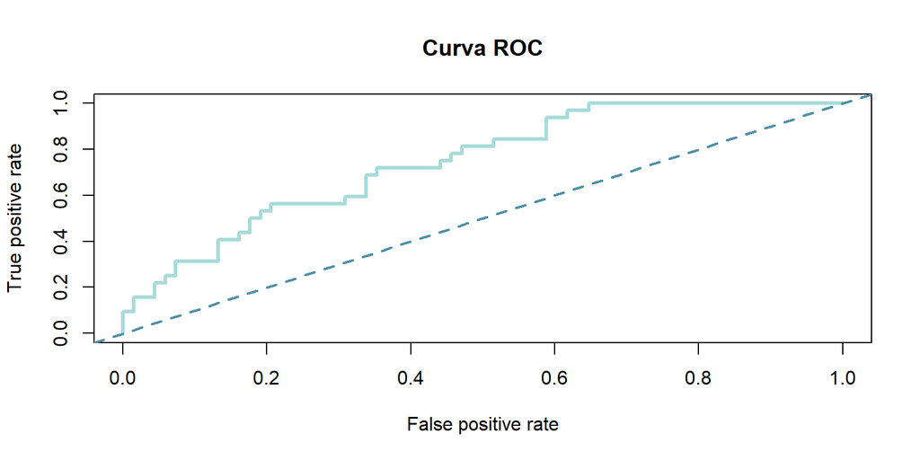

```r
resultados_metricas_boost_10 <- metricas(modelo_boost_10)
print(resultados_metricas_boost_10)
```

Para empezar, el modelo boosting de 10 clasifica correctamente según el accuracy el 71% de los casos totales, dejando por lo tanto un error global del 29%. En términos de credit scoring, esto significa que el modelo predice correctamente si un cliente incumplirá o no su crédito en el 71% de los casos. Como ya sabemos, aunque esta métrica es útil, puede ser engañosa si la clase está desbalanceada.

El índice de Kappa mide la concordancia del modelo con las observaciones reales por encima de lo que se lograría por azar. Un valor de 0.30 sugiere una baja concordancia entre las predicciones y las observaciones reales. En términos de negocio, esto indica que el modelo tiene bastante margen para mejorar y que su rendimiento no es del todo robusto.

Además, según la sensibilidad o recall, el modelo identifica correctamente el 46.88% de los casos de “Default” (verdaderos positivos). En credit scoring, esto significa que el modelo detecta menos de la mitad de los clientes que realmente incumplirán. Esto podría ser problemático porque no identificar a estos clientes podría resultar en pérdidas financieras para la institución.

De acuerdo con la especificidad, el modelo identifica correctamente el 82.35% de los casos de “No-Default” (negativos reales). En este caso, el modelo es mucho mejor para identificar a los clientes que no incumplirán en comparación con los que sí incumplirán. Esto es útil para evitar rechazar clientes solventes, pero no ayuda a mitigar el riesgo de incumplimiento, que es el objetivo principal.

A parte, calculamos el F1 Score, que es el promedio armónico de la precisión y el recall. Un valor de 0.5085 indica un equilibrio moderadamente bajo entre detectar clientes incumplidores (recall) y predecir correctamente cuando lo son (precisión). Es un indicador de que el modelo no está optimizado para los casos positivos (“Default”).

Por último, el Área Bajo la Curva (AUC) es de 0.7431 lo cual significa que el modelo tiene una capacidad bastante buena para distinguir entre las dos clases (en este caso, “Si-Default” y “No-Default”).Un AUC superior a 0.7 generalmente indica un modelo aceptable, aunque no perfecto.

Seguimos con el boosting de 50 trials:

```
       Metric     Value
1    Accuracy 0.6900000
2  Error Rate 0.3100000
3       Kappa 0.2695570
4 Sensitivity 0.4687500
5 Specificity 0.7941176
6   Precision 0.4687500
7    F1 Score 0.4918033
8         AUC 0.7527574
```

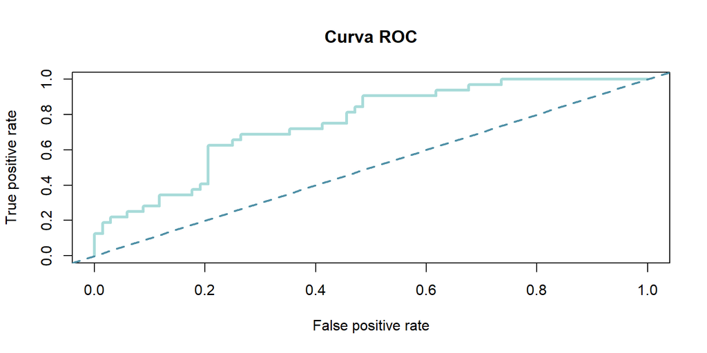

```r
resultados_metricas_boost_50 <- metricas(modelo_boost_50)
print(resultados_metricas_boost_50)
```

El modelo boosting de 50 clasifica correctamente el 69% de los casos totales según el accuracy, dejando un error global del 31%. En términos de credit scoring, esto implica que el modelo predice correctamente si un cliente incumplirá o no su crédito en el 69% de las ocasiones. Sin embargo, como sabemos, esta métrica puede ser engañosa si las clases están desbalanceadas.

El índice de Kappa tiene Un valor de 0.27 sugiere una concordancia moderadamente baja, lo que indica que el modelo tiene bastante margen de mejora y que su rendimiento no es completamente robusto.

Por otro lado, según la sensibilidad o recall, el modelo identifica correctamente el 46.88% de los casos de impago (verdaderos positivos), exactamente igual que en el anterior modelo ya que ambos tienen 17 errores de este tipo.

En cuanto a la especificidad, el modelo clasifica correctamente el 79.41% de los casos de “No-Default” (negativos reales). Esto refleja que el modelo es mejor para identificar clientes que no representan un riesgo en comparación con los que sí lo representan. Si bien esto es útil para evitar rechazar clientes solventes, no contribuye lo suficiente al objetivo principal de mitigar el riesgo de incumplimiento.

El F1 Score, que equilibra la precisión y el recall, tiene un valor de 0.49, lo que sugiere un rendimiento moderadamente bajo del modelo para equilibrar la detección de clientes incumplidores y la precisión en predecirlos correctamente. Esto indica que el modelo no está del todo optimizado para este propósito.

Por último, el Área Bajo la Curva (AUC) es bastante alta de nuevo, por lo tanto el modelo tiene una alta capacidad de discriminación entre las clases. Este valor refleja que el segundo modelo tiene una muy ligera ventaja en la identificación correcta de los clientes con y sin default, en comparación con el primer modelo.

Finalmente lo calculamos con el sensible a costes:

```r
resultados_metricas_cost <- metricas(modelo_cost)
print(resultados_metricas_cost)
```

```
       Metric     Value
1    Accuracy 0.6100000
2  Error Rate 0.3900000
3       Kappa 0.2772424
4 Sensitivity 0.8437500
5 Specificity 0.5000000
6   Precision 0.8437500
7    F1 Score 0.5806452
```

El modelo sensible a costes clasifica correctamente el 61% de los casos, con un error del 39%. Aunque esta métrica es útil, puede ser engañosa en clases desbalanceadas, por lo que es necesario revisar otras métricas.

El índice de Kappa es de 0.277, lo que indica una baja concordancia entre las predicciones y los resultados reales, lo que sugiere que el modelo aún puede mejorar.

La sensibilidad (84.38%) muestra que el modelo detecta bien los clientes en riesgo de incumplir, mientras que la especificidad (50%) indica que no es tan efectivo para identificar a los clientes solventes.

El F1 Score es de 0.5806, lo que refleja un equilibrio moderado entre la sensibilidad y la precisión.

El AUC no se puede calcular ya que el modelo no utiliza probabilidades, sino que aplica umbrales directos, limitando su capacidad para evaluar la calidad de las predicciones a través de distintos umbrales.

En conclusión, siendo objetivo principal mitigar el riesgo de impago y priorizar la detección de clientes incumplidores, el modelo sensible a costes es la mejor opción. A pesar de sus limitaciones en la identificación de clientes solventes, su alta sensibilidad y su capacidad para detectar la mayoría de los incumplimientos lo hacen más adecuado para nuestras necesidades como vamos a ver a continuación.

## 7. Estrategia agresiva o una conservadora basada en los outputs

En el contexto del credit scoring, la decisión de adoptar una estrategia conservadora o agresiva depende de los riesgos asociados a los errores de clasificación. Tras analizar el caso de estudio, consideramos que una estrategia conservadora es la más adecuada en este escenario, ya que se trata de una evaluación de riesgo financiero al conceder un préstamo.

## 9. Threshold que maximiza los beneficios y la rentabilidad

Recuperamos la probabilidad estimada de pertenencia a la clase de fraude y la metemos en el objeto y_proba, luego convertimos la variable objetivo a numérica y le restamos 1 para que No-Default sea 0 y Si-Default sea 1 y este resultado de unos y ceros lo guardamos en el objeto y_true. Después, siguiendo el enunciado del ejercicio, creamos los valores beneficio_no_default, que es el beneficio obtenido del tipo de interés para 1000 u.m. en caso de no fraude, y perdida_default, que nos indica las pérdidas esperadas derivadas de un fraude para 1000 u.m.

```r
y_proba <- predic_prob[, "Si-Default"]

y_true <- as.numeric(test$default) - 1

beneficio_no_default <- 1000*0.25
perdida_default <- 1000*0.6
```

Por último, antes de crear el algoritmo, inicializamos el threshold, es decir, el valor o límite que se utiliza para determinar si se cumple o no una condición particular, en 0, y el beneficio y la rentabilidad máxima en infinito.

```r
threshold_optimo_ben <- 0
threshold_optimo_rent <- 0

beneficio_maximo <- -Inf
rentabilidad_maxima <- -Inf
```

Ahora ya podemos crear el algoritmo probando con thresholds entre 0.1 y 1 de 0.01 en 0.01 y calculando con estos el beneficio y la rentabilidad. Después, si el beneficio con el nuevo threshold es mayor que con el anterior se actualiza el threshold óptimo pasando a ser el último.

**Mostrar código**

```r
for (threshold in seq(0.1, 1, by = 0.01)) {
  TP <- sum(y_proba >= threshold & y_true == 1)
  FP <- sum(y_proba >= threshold & y_true == 0)
  TN <- sum(y_proba < threshold & y_true == 0)
  FN <- sum(y_proba < threshold & y_true == 1)

  beneficio <- (TN * beneficio_no_default) - (FN * perdida_default) - (FP * beneficio_no_default)

  total_inversion <- (TP + FN) * perdida_default  #Total invertido
  rentabilidad <- (beneficio / total_inversion)*100

  if (beneficio > beneficio_maximo) {
    beneficio_maximo <- beneficio
    threshold_optimo_ben <- threshold
  }

  if (rentabilidad > rentabilidad_maxima) {
    rentabilidad_maxima <- rentabilidad
    threshold_optimo_rent <- threshold
  }
}
```

Ahora creamos las predicciones usando el umbral óptimo y recuperamos y_true como factor con los niveles No-Default y Si-Default para la matriz de confusión.

```r
y_pred <- ifelse(y_proba >= threshold_optimo_ben, "Si-Default", "No-Default")

y_true_factor <- test$default

CrossTable(x = y_true_factor, y = y_pred, prop.chisq = FALSE,
           prop.c = FALSE, prop.r = FALSE, dnn = c('REAL', 'PREDICCIÓN'))
```

```
   Cell Contents
|-------------------------|
|                       N |
|         N / Table Total |
|-------------------------|


Total Observations in Table:  100


             | PREDICCIÓN
        REAL | No-Default | Si-Default |  Row Total |
-------------|------------|------------|------------|
  No-Default |         56 |         12 |         68 |
             |      0.560 |      0.120 |            |
-------------|------------|------------|------------|
  Si-Default |         15 |         17 |         32 |
             |      0.150 |      0.170 |            |
-------------|------------|------------|------------|
Column Total |         71 |         29 |        100 |
-------------|------------|------------|------------|
```

## 10. Sesgo más importante de los datos

El sesgo más común en datos de crédito es el sesgo de selección. Las entidades financieras generalmente solo tienen información detallada sobre aquellos clientes a los que han otorgado créditos en el pasado, por lo que carecen de datos sobre personas rechazadas. Esto significa que el modelo puede subestimar el riesgo de aquellos que serían rechazados. Además, otro sesgo es que las variables históricas pueden no reflejar cambios en las condiciones económicas o políticas futuras, lo que afecta la capacidad de generalización del modelo.

## 11: Referencias

[Mastering Markdown Basics in Quarto: A comprehensive guide to enhancing your documentation.](https://www.datanovia.com/guide/tools/quarto/markdown-basics.html)

[Vega, J. B. M. (n.d.). R para principiantes.](https://bookdown.org/jboscomendoza/r-principiantes4/if-else.html)

[Chugh, V. (2024, October 1). AUC y Curva ROC en Aprendizaje Automático.](https://www.datacamp.com/es/tutorial/auc)